# Dashboard

Henry Linder (mhlinder@gmail.com)

January 15, 2017

# Setup

```r
library(magrittr)
library(dplyr)
library(knitr)
```

## Graphical parameters

```r
get_colors <- function(url = "https://coolors.co/033f63-28666e-7c9885-b5b682-fedc97") {
    ## `url` should be a link to a coolors.co color scheme
    ## Returns a vector with the palette's hex codes as character elements.
    basename(url) %>%
        strsplit("-") %>%
        unlist %>%
        paste0("#", .)
}

colors5 <- get_colors("https://coolors.co/033f63-28666e-7c9885-b5b682-fedc97")
colors7 <- c("#8569CF", "#0D9FD8", "#8AD749", "#EECE00",
             "#F8981F", "#F80E27", "#F640AE")

## List of all weekday names, starts on Sunday
dows <- weekdays(x=as.Date(seq(7), origin="1949-12-31"))
wknd <- dows %in% c("Saturday", "Sunday")

names(colors7) <- dows
```

A cronjob executes every two weeks, which runs the file `get_data.R` (the source is included at the end of this file). The script saves a dated file in the directory `data/`.

```r
infiles <- list.files("data", full.names = TRUE)
n_infiles <- length(infiles)
infiles[n_infiles]
```

```
## [1] "data/2017-01-13.Rdata"
```

We load the most recent data file, which contains the master variable `out`.

```r
load(infiles[n_infiles])

daily <-
    out$daily %>%
    as.data.frame %>%
    tbl_df %>%
    rename(steps = steps.steps)

## Removes day zero, which does not record a full day
daily <- daily[-1,]
n <- nrow(daily)

## Removes day n, which is incomplete by dint of when the data was collected
daily <- daily[-n,]
n <- nrow(daily)

names(out)
```

```
## [1] "activity" "daily"    "intraday" "sleep"    "weight"
```

# EDA

We start by considering daily historical step count, which is stored in `daily$steps.time`. We also check whether there are any missing days, because we assume there are none.

```r
daily$dates <-
    daily$steps.time %>%
    as.Date

all_days <-
    seq.Date(daily$dates[1], daily$dates[n], by = "day") %>%
    as.character
d <- as.character(daily$dates)

if (!all(d == all_days)) {
    stop("Missing days in input data!")
}
```

## Weekdays and weekends

We consider a simple time series plot to consider the data,

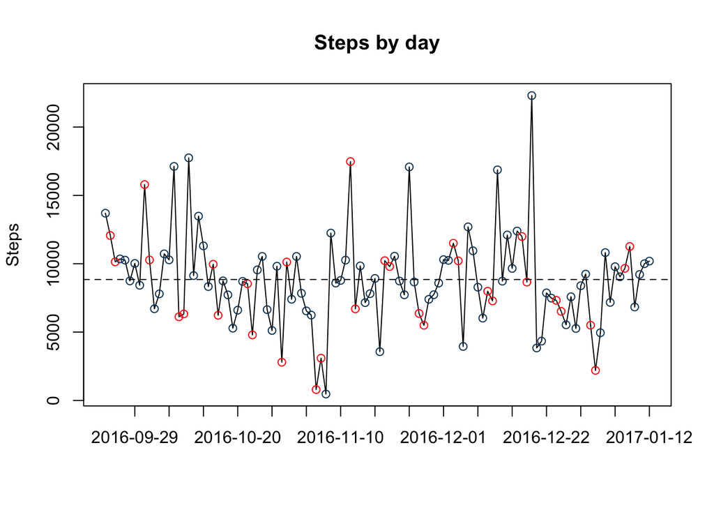

```r
daily$dow <- weekdays(daily$dates) ## Weekday of each observation
daily$is_wknd <- daily$dow %in% c("Saturday", "Sunday")

## Find the first day, so the colors match the dates
st1 <- daily$dow[1]
ix_st <- which(colors7 %>% names == st1)
## This vector of indexes rearranges the week starting on day 1, to a
## week startin gon day ix_st
ix <- c((ix_st:7), (1:(ix_st-1)))

tmp_color <- rep(colors5[1], 7)
tmp_color[wknd] <- "red"
names(tmp_color) <- dows
tmp_color <- tmp_color[ix]

plot(daily$dates, daily$steps, type = "l",
     xlab = "",
     ylab = "Steps",
     main = "Steps by day",
     xaxt = "n")
points(daily$dates, daily$steps, col = tmp_color)

## Count backwards by week from the last observation
at <- seq.Date(daily$dates[n], daily$dates[1], by = "-1 week")
axis(1, at = at, labels = as.character(at))

abline(h = mean(daily$steps), lty = 2)
```

where the red dots label weekends, and the dotted line represents the mean. Although the time series is noisy, there appears to be some cyclical trend.

Further, on many occasions, the weekend points are very close to each other—ie, their correlations seem high.

```r
sat <- daily %>% filter(dow == "Saturday")
sun <- daily %>% filter(dow == "Sunday")

if (nrow(sat) != nrow(sun)) {
    stop("Incomplete weekends!")
}

n_wknd <- nrow(sat)

ix_match <-
    sapply(1:n_wknd, function(x) {
        if (as.double(sun$dates[1] - sat$dates[1]) != 1) {
            FALSE
        } else {
            TRUE
        }})
sun <- sun[ix_match,]
sat <- sat[ix_match,]

cor(sat$steps, sun$steps)
```

```
## [1] 0.4736355
```

This seems to suggest moderate association between the number of steps taken on Saturdays and Sundays.

```r
cor.test(sat$steps, sun$steps, method = "pearson")
```

```
##
##  Pearson's product-moment correlation
##
## data:  sat$steps and sun$steps
## t = 2.0122, df = 14, p-value = 0.06385
## alternative hypothesis: true correlation is not equal to 0
## 95 percent confidence interval:
##  -0.02884129  0.78502889
## sample estimates:
##       cor
## 0.4736355
```

```r
cor.test(sat$steps, sun$steps, method = "kendall")
```

```
##
##  Kendall's rank correlation tau
##
## data:  sat$steps and sun$steps
## T = 85, p-value = 0.02554
## alternative hypothesis: true tau is not equal to 0
## sample estimates:
##       tau
## 0.4166667
```

```r
cor.test(sat$steps, sun$steps, method = "spearman")
```

```
##
##  Spearman's rank correlation rho
##
## data:  sat$steps and sun$steps
## S = 292, p-value = 0.02318
## alternative hypothesis: true rho is not equal to 0
## sample estimates:
##       rho
## 0.5705882
```

In other words, either it’s a walking weekend, or a resting weekend, but I rarely walk a lot on only one day of a weekend.

We also compare kernel density plots of the observations for weekends and weekdays.

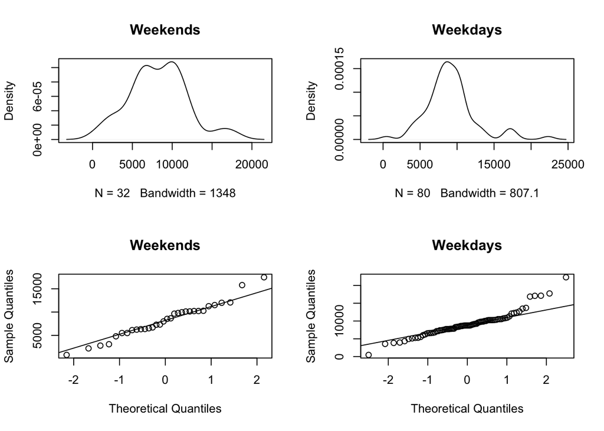

```r
par(mfrow = c(2,2))

data_weekends <-
    daily %>%
    filter(is_wknd)
data_weekdays <-
    daily %>%
    filter(!is_wknd)

plot(density(data_weekends$steps), main = "Weekends")

plot(density(data_weekdays$steps), main = "Weekdays")

qqnorm(data_weekends$steps, main = "Weekends")
qqline(data_weekends$steps)

qqnorm(data_weekdays$steps, main = "Weekdays")
qqline(data_weekdays$steps)
```

Notable features include the much longer right tail for the weekday distribution, and the larger left tail for weekends. This reflects a pattern that I walk the furthest on weekdays, sometimes quite far, whereas on the weekends I am much less likely to go on a very long walk.

```r
mean(data_weekends$steps)
```

```
## [1] 8224.938
```

```r
mean(data_weekdays$steps)
```

```
## [1] 9095.125
```

```r
sd(data_weekends$steps)
```

```
## [1] 3660.843
```

```r
sd(data_weekdays$steps)
```

```
## [1] 3360.975
```

## Day-of-the-week

Then, we can consider day-of-the-week breakdowns, like the average steps per day:

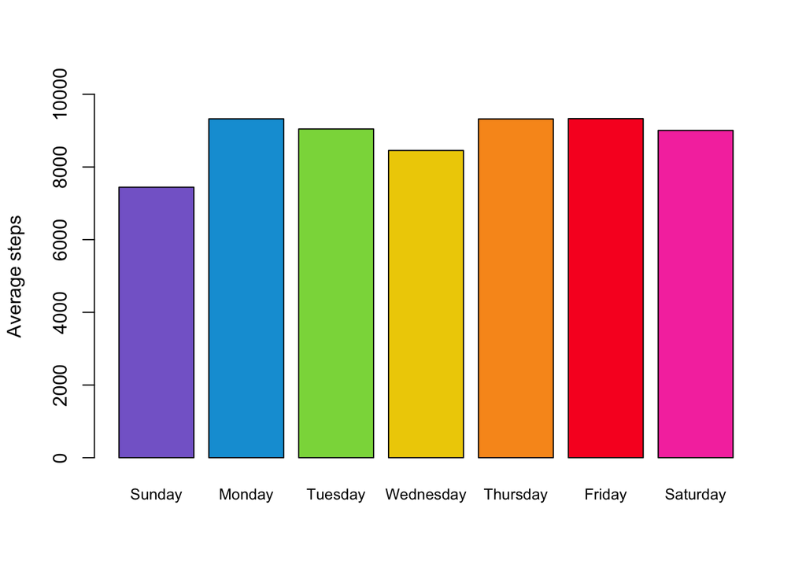

```r
## Indexes of dates by day-of-week
ix_dow <- list()
for (d in dows) {
    ix_dow[[d]] <- which(daily$dow == d)
}

x <-
    ix_dow %>%
    lapply(function(ix) mean(daily$steps[ix])) %>%
    unlist

barplot(x, col = colors7,
        cex.names = .8,
        ylim = c(0, 10000), ylab = "Average steps")
```

These daily values look pretty similar to each other, and an ANOVA test for a difference in means may provide a useful way to summarize the data.

Density plots for all days together, and by each day:

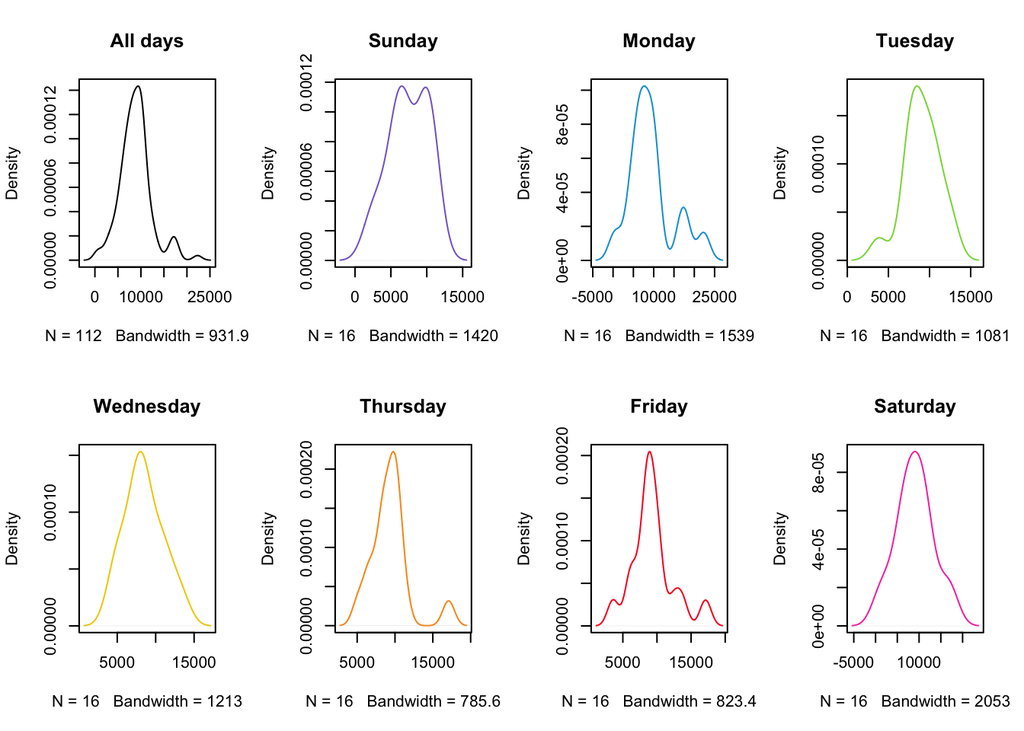

```r
par(mfrow = c(2, 4))

plot(density(daily$steps), main = "All days")
for (dow in dows) {
    plot(density(daily$steps[ix_dow[[dow]]]),
           main = dow, col = colors7[dow])
}
```

For all days, and each day, normal probability plots:

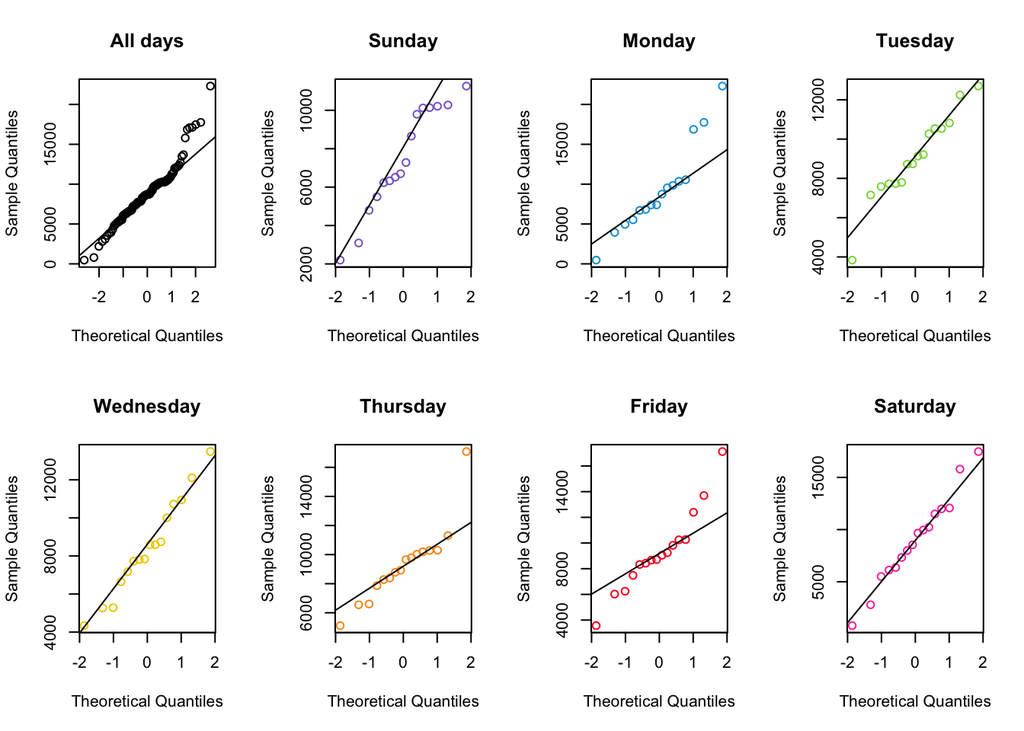

```r
par(mfrow = c(2, 4))

qqnorm(daily$steps, main = "All days")
qqline(daily$steps)
for (dow in dows) {
    qqnorm(daily$steps[ix_dow[[dow]]],
           main = dow, col = colors7[dow])
    qqline(daily$steps[ix_dow[[dow]]])
}
```

These distributions are symmetric and approximately unimodal, so the data can be said to be approximately normal—at least for our purposes, “approximate” normality suffices. This is because ANOVA is robust to deviations from normality, generally speaking.

Recall from above that the weekend and weekday datasets were each approximately normal, so we can conduct two ANOVA tests.

```r
aov(steps ~ dow, data = daily) %>%
    summary
```

```
##              Df    Sum Sq  Mean Sq F value Pr(>F)
## dow           6 4.602e+07  7669471    0.63  0.706
## Residuals   105 1.279e+09 12182306
```

The first ANOVA considers each day to be a separate population, and the test pretty conclusively fails to reject the null hypothesis of zero difference. In other words, **from a statistical perspect, there is no difference in average numbers of steps per day between different days of the week.**

```r
aov(steps ~ is_wknd, data = daily) %>%
    summary
```

```
##              Df    Sum Sq  Mean Sq F value Pr(>F)
## is_wknd       1 1.731e+07 17308029   1.456   0.23
## Residuals   110 1.308e+09 11889554
```

The test-statistic is larger, the p-value is smaller, but there is still effectively zero support for the hypothesis that my walking habits are different on the weekends from the weekdays, at least in terms of the number of steps I take.

In other words, it does not seem meaningful to consider each day of the week separately, or weekdays and weekends separately. There are likely other, more nuanced subsets possible for the days of the weeK: for instance, last fall I took courses on Tuesdays and Thursdays, and on those days I had a long walk to and from my car.

```r
daily$ttr <- daily$dow %in% c("Tuesday", "Thursday")
aov(steps ~ ttr, data = daily) %>%
    summary
```

```
##              Df    Sum Sq  Mean Sq F value Pr(>F)
## ttr           1 5.099e+06  5099221   0.425  0.516
## Residuals   110 1.320e+09 12000544
```

This doesn’t show up, either.

# Code

## `get_data.R`

```r
#!/usr/bin/Rscript
Sys.setenv(TZ = "America/New_York")

library(magrittr)
library(dplyr)

library(fitbitScraper)

dirpath <- "/home/mlinder/research/fitbit"

start <- "2016-09-22"
start_date <- as.Date(start, "%Y-%m-%d")
today_date <- Sys.Date()
today <- format(today_date, "%Y-%m-%d")


## Provides user, pass
source(file.path(dirpath, "secret.R"))

l <- login(user, pass)

out <- list()

print("Fetching activity data...")
out$activity <- get_activity_data(l, today)

print("Fetching daily data...")
out$daily <- list()
## for (v in c("steps", "distance", "floors", "minutesVery", "caloriesBurnedVsIntake", "getTimeInHeartRateZonesPerDay")) {
for (v in "steps") {
    print(sprintf("  - Fetching %s", v))
    out$daily[[v]] <- get_daily_data(l, v, start, today)
}

print("Fetching intraday data...")
out$intraday <- list()
daylist <- as.character(seq(start_date, today_date, 1))
for (d in daylist) {
    print(sprintf("  - %s", d))

    tmp <- list()
    for (v in c("steps", "distance", "floors", "active-minutes", "calories-burned", "heart-rate")) {
        print(sprintf("      - Fetching %s", v))
        tmp[[v]] <- get_intraday_data(l, v, d)
    }

    out$intraday[[d]] <- tmp
}

print("Fetching sleep data...")
out$sleep <- get_sleep_data(l, start, today)

print("Fetching weight data...")
out$weight <- get_weight_data(l, start, today)

save(out, file = file.path(dirpath, sprintf("data/%s.Rdata", today)))
```